# Taxonomic Composition and Abundance analysis of snail gut microbiome with temperature and sex variables

Daphne Garcia

2025-04-23

## Goals

In this file, I performed compositional analysis of the scaled/noramlized/rarefied snail intestinal-microbiome dataset.

1. Calculate the relative abundances of taxonomic groups at various levels: A. Phylum B. Genus C. ASV against variables temperature and sex
2. Plot Phylum and ASV level for Pseudomonadota, Bacillota, Bacteroidetes, Lactococcus, Enterobacter, and Eurkholderia

Hypotheses:

HA1: The abundance of pathogenic Pseudomonadota taxa will be higher in the high-temperature groups compared to control and low temperatures

HA2: The abundance of immune-related Bacillota and Bacteroidetes taxa will be lower in the high-temperature groups compared to control and low temperatures

H0: There will be no difference in abundance of any taxa in the high-temperature groups compared to control and low temperatures

scaled_physeq.RData: a rooted tree from `06_Ordination.rmd`.

### Outputs

microbial taxa abundance plots against temperature and sex, with statistical testing

INTERPRETATION #1: What are the limitations of interpreting microbial abundance from relative (aka. compositional) rather than absolute counts?

The main limitation of using relative abundance instead of absolute abundance is that we are unable to truly compare different datasets against one another. Unlike absolute counts, the size of a sample and the relative abundance of other taxa have a large weight on the measurement of relative abudnance. Specifically if we are looking at datasets across time, temperature, salinity, or another gradients, a signal that may appear to be an increase or decrease in abundance of a specific phyla may be falsely impacted by a difference in the sizes of the samples, or even by a large change in abundance from another phyla. For example, a specific taxonomic group may appear to decline in relative abundance simply because another taxon increased in abundance, not because the first one actually decreased.

# Load in Scaled Phyloseq object

```r
load("data/06_Ordination/scaled_physeq.RData")

# Look at the data
scaled_physeq
```

```
## phyloseq-class experiment-level object
## otu_table()   OTU Table:         [ 17799 taxa and 60 samples ]
## sample_data() Sample Data:       [ 60 samples by 41 sample variables ]
## tax_table()   Taxonomy Table:    [ 17799 taxa by 9 taxonomic ranks ]
## phy_tree()    Phylogenetic Tree: [ 17799 tips and 17798 internal nodes ]
```

```r
# Intuition check - scaled at 1,942
min(sample_sums(scaled_physeq))
```

```
## [1] 39159
```

```r
range(sample_sums(scaled_physeq))
```

```
## [1] 39159 39338
```

# Phylum analysis

```r
# Create a phylum level dataframe
phylum_df <-
  scaled_physeq %>%
  # Agglomerate all ASV counts within a phylum
  tax_glom(taxrank = "Phylum") %>%
  # Calculate the relative abundance!
  transform_sample_counts(function(x) {x/sum(x)}) %>%
  # Create a dataframe from phyloseq object
  psmelt() %>%
  # Filter out Phyla < 1 %
  #dplyr::filter(Abundance > 0.01)
  mutate(temperature = fct_relevel(temperature, c("L", "C", "H")))


## What are the phylum abundances?
phylum_df %>%
  group_by(Phylum) %>%
  summarize(mean_PercAbund = round(mean(Abundance), digits = 4)) %>%
  arrange(-mean_PercAbund) %>%
  datatable()
```

|  | Phylum | mean_PercAbund |
| --- | --- | --- |
| 1 | Pseudomonadota | 0.5202 |
| 2 | Bacillota | 0.2503 |
| 3 | Bacteroidota | 0.1979 |
| 4 | Spirochaetota | 0.0062 |
| 5 | Thermodesulfobacteriota | 0.0055 |
| 6 | Verrucomicrobiota | 0.0054 |
| 7 | Acidobacteriota | 0.0036 |
| 8 | Bdellovibrionota | 0.0032 |
| 9 | Myxococcota | 0.0028 |
| 10 | Actinomycetota | 0.0014 |

[output cut: 35 more lines]

# Make a list of phyla the top phyla

```r
# Make a list of phyla the top phyla
top10_phyla <-
  phylum_df %>%
  group_by(Phylum) %>%
  summarize(mean_PercAbund = mean(Abundance)) %>%
  arrange(-mean_PercAbund) %>%
  head(n = 10) %>%
  pull(Phylum)
```

INTERPRETATION #2: Which phyla in your dataset have the highest relative abundances? What are their abundances? We will focus on these phyla for plotting below. :)

# Stacked Bar Plot With All phyla of temperature

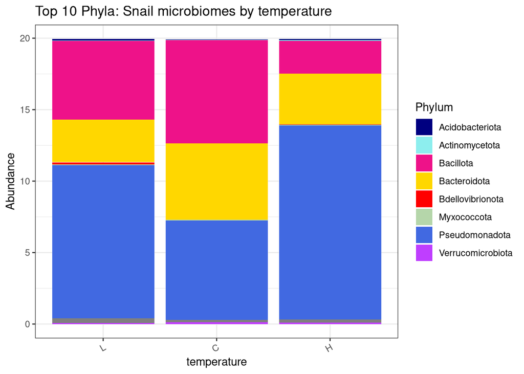

```r
# Stacked Bar Plot With All phyla
# Plot Phylum Abundances - make sure to load phylum_colors
phylum_df %>%
  dplyr::filter(Phylum %in% top10_phyla) %>%
  # Warning: It's important to have one sample per x value,
  # otherwise, it will take the sum between multiple samples
  #dplyr::filter(depth == 0.0) %>%                ############ commented out
  #dplyr::filter(fraction == "Whole") %>%         ############ commented out
  ggplot(aes(x = temperature, y = Abundance, fill = Phylum)) +
  # facet_grid(.~temperature) +
  geom_bar(stat = "identity") +
  labs(title = "Top 10 Phyla: Snail microbiomes by temperature") +
  scale_fill_manual(values = phylum_colors) +
  theme_bw() +
  theme(axis.text.x = element_text(angle = 30, hjust = 1, vjust = 1))
```

# Stacked barplot of temperature_and_sex

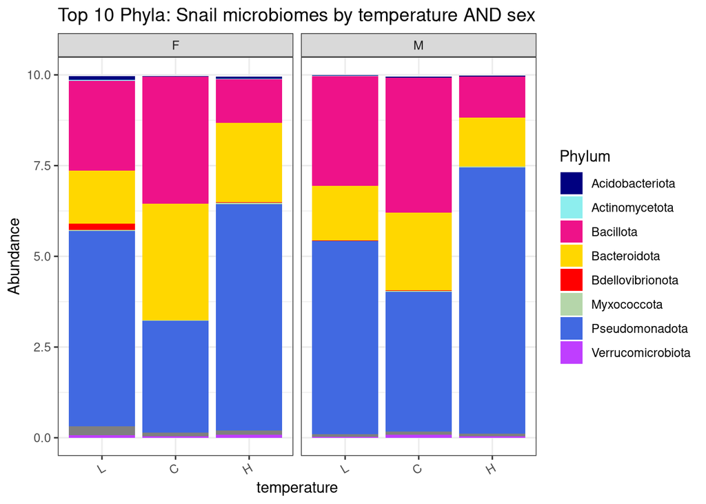

```r
# Stacked Bar Plot With All phyla
# Plot Phylum Abundances - make sure to load phylum_colors
phylum_df %>%
  dplyr::filter(Phylum %in% top10_phyla) %>%
  # Warning: It's important to have one sample per x value,
  # otherwise, it will take the sum between multiple samples
  #dplyr::filter(depth == 0.0) %>%                ############ commented out
  #dplyr::filter(fraction == "Whole") %>%         ############ commented out
  ggplot(aes(x = temperature, y = Abundance, fill = Phylum)) +
  facet_grid(.~sex) +
  geom_bar(stat = "identity") +
  labs(title = "Top 10 Phyla: Snail microbiomes by temperature AND sex ") +
  scale_fill_manual(values = phylum_colors) +
  theme_bw() +
  theme(axis.text.x = element_text(angle = 30, hjust = 1, vjust = 1))
```

SEX by TEMP Note: when I separate by temperature AND sex, I see that Female snails at Hi and Low temp have more acidobacteroita than males at same temp. Also, the abundances of the top 3 (pseudomonadota, bacillota, bacteroidota) are visually different. Would be cool to runs a stats test

TEMP by SEX This looks so much more even, the corresponding M and F groups at each temp mirror each other. So, male and female snails do seem to have different microbiomes, but they change the same ways when exposed to heat or cold.

# Faceted Bar plot of temperature variable

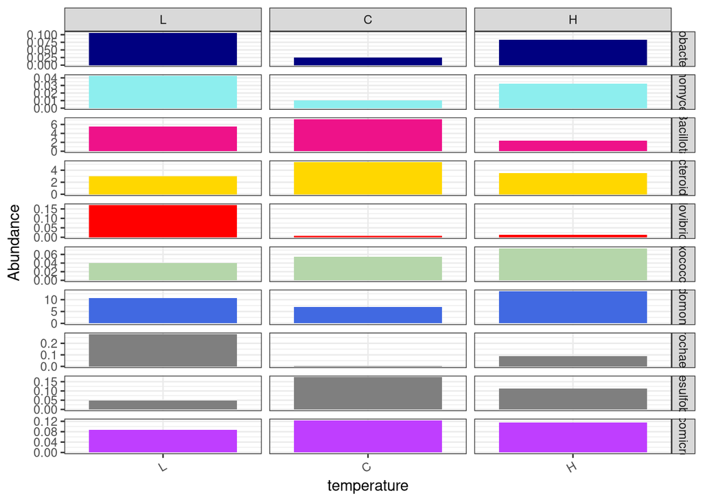

```r
phylum_df %>%
  dplyr::filter(Phylum %in% top10_phyla) %>%
  # Individual sample comparison of surface waters, whole fraction
  # This will allow us to look at individual samples!
  # Note that whenever plotting stacked bar plots, you should always look at Individual samples!
  #dplyr::filter(depth == 0.0) %>%
  #dplyr::filter(fraction == "Whole") %>%
  ggplot(aes(x = temperature, y = Abundance, fill = Phylum)) +
  facet_grid(Phylum~temperature, scale = "free") +
  # add the stacked bar
  geom_bar(stat = "identity") +
  # change the colors to be our selected colors
  scale_fill_manual(values = phylum_colors) +
  theme_bw() +
  theme(legend.position = "none",
        axis.text.x = element_text(angle = 30, hjust = 1, vjust = 1))
```

# Faceted barplot by temperature and sex

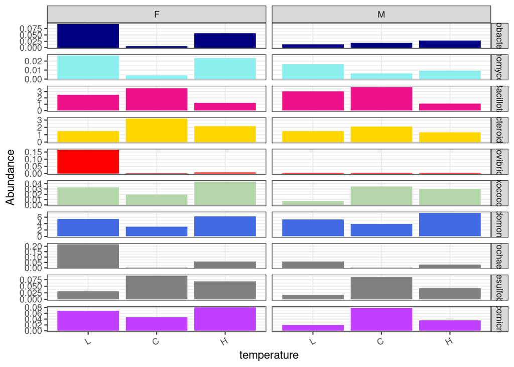

```r
phylum_df %>%
  dplyr::filter(Phylum %in% top10_phyla) %>%
  # Individual sample comparison of surface waters, whole fraction
  # This will allow us to look at individual samples!
  # Note that whenever plotting stacked bar plots, you should always look at Individual samples!
  #dplyr::filter(depth == 0.0) %>%
  #dplyr::filter(fraction == "Whole") %>%
  ggplot(aes(x = temperature, y = Abundance, fill = Phylum)) +
  facet_grid(Phylum~sex, scale = "free") +
  # add the stacked bar
  geom_bar(stat = "identity") +
  # change the colors to be our selected colors
  scale_fill_manual(values = phylum_colors) +
  theme_bw() +
  theme(legend.position = "none",
        axis.text.x = element_text(angle = 30, hjust = 1, vjust = 1))
```

This is interesting, when looking at just temperature (not by sex), there are many minor phyla that have a visually different abundance in the cold, or grow from control to high to low. HOWEVER, there is a pattern for the top three phyla (pseudomonadota, bacillota, bacteroidota), where there is a difference in the high temperature compared to control and low. for pseudomonadota (blue), it is higher abundance at high-temperature. for Bacillota, it is much lower abundance at high temperature, which the paper also concluded. For bacteroidota, however, there is highest abundance at control, and lower abundance at high and low temperatures. When separating by temperature and sex, these patterns hold for both female and male snails.

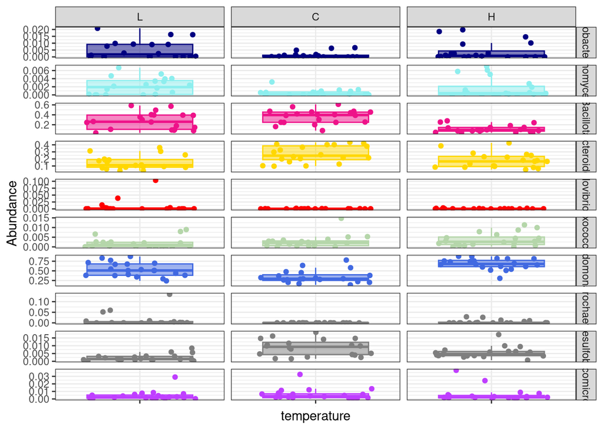

```r
### Or combined together:
phylum_df %>%
  dplyr::filter(Phylum %in% top10_phyla) %>%
  ggplot(aes(x = temperature, y = Abundance, fill = Phylum, color = Phylum)) +
  facet_grid(Phylum~temperature, scale = "free") +
  # add the stacked bar
  geom_jitter() +
  geom_boxplot(outlier.shape = NA, alpha = 0.5) +
  # change the colors to be our selected colors
  scale_fill_manual(values = phylum_colors) +
  scale_color_manual(values = phylum_colors) +
  theme_bw() +
  theme(legend.position = "none",
        axis.text.x = element_text(angle = 30, hjust = 1, vjust = 1, size = 0.5))
```

INTERPRETATION #3: Make the above dotplot and boxplot for your sample types and your most abundant phyla. What initial conclusions can you draw regarding the sampled microbial communities as it relates to your scientific question?

## A1: Pseudomonadota (most abundant, high at high temp)

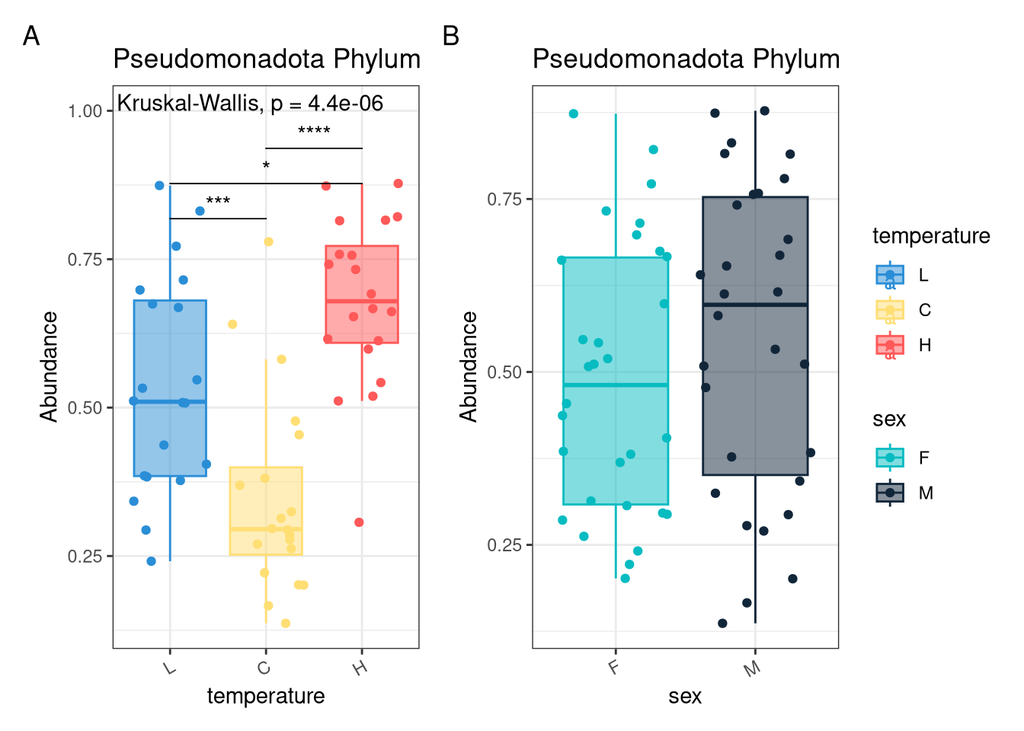

```r
# Narrow in on a specific group
# Pseudomonadota - y: abundance, x: station, dot plot + boxplot
pseudo_phylum_temp <-
  phylum_df %>%
  dplyr::filter(Phylum == "Pseudomonadota") %>%
  # build the plot
  ggplot(aes(x = temperature, y = Abundance,
             fill = temperature, color = temperature)) +
  geom_boxplot(alpha = 0.5, outlier.shape = NA) + # outliers not plotted here in boxplot
  geom_jitter() +
  theme_bw() +
  labs(title = "Pseudomonadota Phylum") +
  scale_color_manual(values = temperature_colors) +
  scale_fill_manual(values = temperature_colors) +
    stat_compare_means(method = "kruskal.test", label.y = 1) +  # KRUSKAL p-value (not normal)
  geom_pwc(
    aes(group = temperature), tip.length = 0, hide.ns = TRUE,
    method = "wilcox.test", label = "p.adj.signif",
    step.increase = 0.08,
    p.adjust.method = "fdr", bracket.nudge.y = -0.08) +

    theme(axis.text.x = element_text(angle = 30, hjust = 1, vjust = 1),
          legend.position = "right")
# Statistically: Kruskall-Wallis followed by a Tukey's Posthoc test
# These are non-parametric (non-normal) stat tests


# SEX
pseudo_phylum_sex <-
  phylum_df %>%
  dplyr::filter(Phylum == "Pseudomonadota") %>%
  # build the plot
  ggplot(aes(x = sex, y = Abundance,
             fill = sex, color = sex)) +
  geom_boxplot(alpha = 0.5, outlier.shape = NA) + # outliers not plotted here in boxplot
  geom_jitter() +
  theme_bw() +
  labs(title = "Pseudomonadota Phylum") +
  scale_color_manual(values = sex_colors) +
  scale_fill_manual(values = sex_colors) +
    theme(axis.text.x = element_text(angle = 30, hjust = 1, vjust = 1),
          legend.position = "right")
# Statistically: Kruskall-Wallis followed by a Tukey's Posthoc test
# These are non-parametric (non-normal) stat tests

# Collect both of the plots together into one
pseudo_phylum_temp + pseudo_phylum_sex +
  plot_layout(guides = "collect") +
  plot_annotation(tag_levels = "A")
```

Sure, forward with this

## A2: Bacillota (second most abundant, low at high temp)

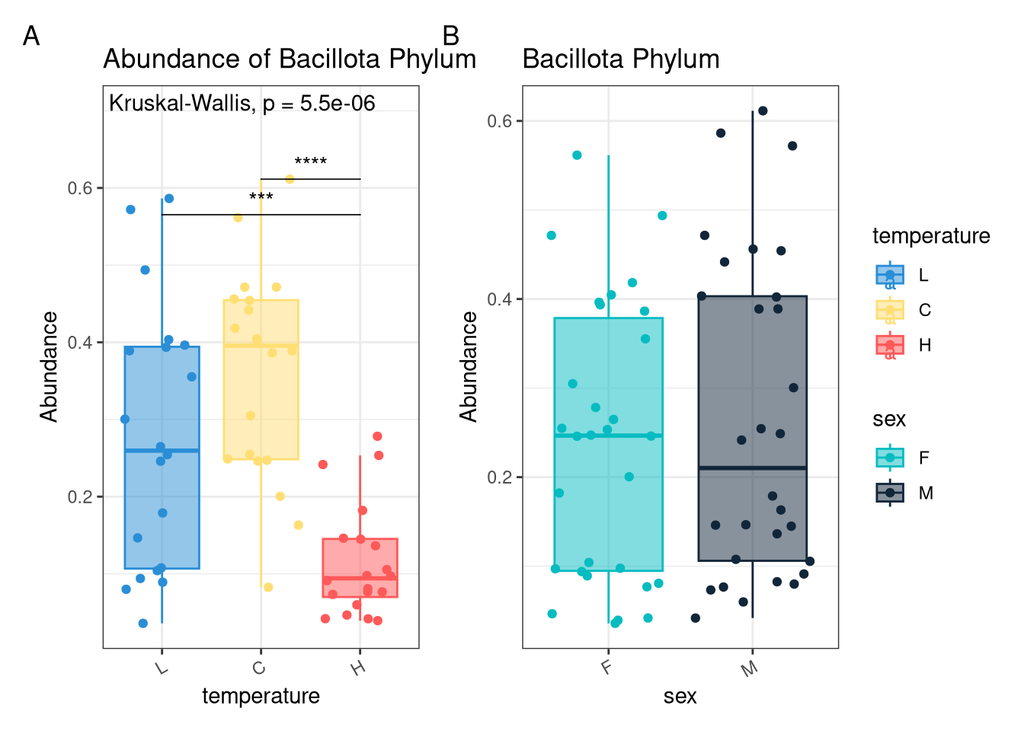

```r
# Pseudomonadota - y: abundance, x: station, dot plot + boxplot
bacil_phylum_temp <-
  phylum_df %>%
  dplyr::filter(Phylum == "Bacillota") %>%
  # build the plot
  ggplot(aes(x = temperature, y = Abundance,
             fill = temperature, color = temperature)) +
  geom_boxplot(alpha = 0.5, outlier.shape = NA) + # outliers not plotted here in boxplot
  geom_jitter() +
  theme_bw() +
  labs(title = "Abundance of Bacillota Phylum") +
  scale_color_manual(values = temperature_colors) +
  scale_fill_manual(values = temperature_colors) +

  stat_compare_means(method = "kruskal.test", label.y = 0.7) +  # KRUSKAL p-value (not normal)
  geom_pwc(
    aes(group = temperature), tip.length = 0, hide.ns = TRUE,
    method = "wilcox.test", label = "p.adj.signif",
    step.increase = 0.08,
    p.adjust.method = "fdr", bracket.nudge.y = -0.08) +
  theme_bw() +
    theme(axis.text.x = element_text(angle = 30, hjust = 1, vjust = 1),
          legend.position = "right")
# Statistically: Kruskall-Wallis followed by a Tukey's Posthoc test
# These are non-parametric (non-normal) stat tests


# SEX
bacil_phylum_sex <-
  phylum_df %>%
  dplyr::filter(Phylum == "Bacillota") %>%
  # build the plot
  ggplot(aes(x = sex, y = Abundance,
             fill = sex, color = sex)) +
  geom_boxplot(alpha = 0.5, outlier.shape = NA) + # outliers not plotted here in boxplot
  geom_jitter() +
  theme_bw() +
  labs(title = "Bacillota Phylum") +
  scale_color_manual(values = sex_colors) +
  scale_fill_manual(values = sex_colors) +
    theme(axis.text.x = element_text(angle = 30, hjust = 1, vjust = 1),
          legend.position = "right")
# Statistically: Kruskall-Wallis followed by a Tukey's Posthoc test
# These are non-parametric (non-normal) stat tests

# Collect both of the plots together into one
bacil_phylum_temp + bacil_phylum_sex +
  plot_layout(guides = "collect") +
  plot_annotation(tag_levels = "A")
```

Definitely move forward with this one

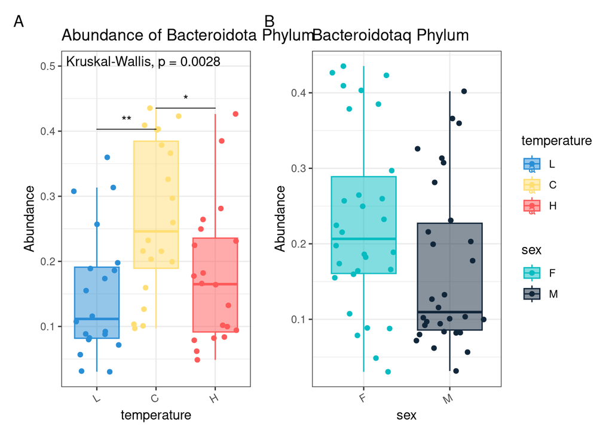

```r
# Bacteroidetes - y: abundance, x: station, dot plot + boxplot
bacter_phylum_temp <-
  phylum_df %>%
  dplyr::filter(Phylum == "Bacteroidota") %>%
  # build the plot
  ggplot(aes(x = temperature, y = Abundance,
             fill = temperature, color = temperature)) +
  geom_boxplot(alpha = 0.5, outlier.shape = NA) + # outliers not plotted here in boxplot
  geom_jitter() +
  stat_compare_means(method = "kruskal.test", label.y = 0.5) +  # KRUSKAL p-value (not normal)
  geom_pwc(
    aes(group = temperature), tip.length = 0, hide.ns = TRUE,
    method = "wilcox.test", label = "p.adj.signif",
    step.increase = 0.08,
    p.adjust.method = "fdr", bracket.nudge.y = -0.08) +
  theme_bw() +
  labs(title = "Abundance of Bacteroidota Phylum") +
  scale_color_manual(values = temperature_colors) +
  scale_fill_manual(values = temperature_colors) +
    theme(axis.text.x = element_text(angle = 30, hjust = 1, vjust = 1),
          legend.position = "right")
# Statistically: Kruskall-Wallis followed by a Tukey's Posthoc test
# These are non-parametric (non-normal) stat tests


# SEX
bacter_phylum_sex <-
  phylum_df %>%
  dplyr::filter(Phylum == "Bacteroidota") %>%
  # build the plot
  ggplot(aes(x = sex, y = Abundance,
             fill = sex, color = sex)) +
  geom_boxplot(alpha = 0.5, outlier.shape = NA) + # outliers not plotted here in boxplot
  geom_jitter() +
  theme_bw() +
  labs(title = "Bacteroidotaq Phylum") +
  scale_color_manual(values = sex_colors) +
  scale_fill_manual(values = sex_colors) +
    theme(axis.text.x = element_text(angle = 30, hjust = 1, vjust = 1),
          legend.position = "right")
# Statistically: Kruskall-Wallis followed by a Tukey's Posthoc test
# These are non-parametric (non-normal) stat tests

# Collect both of the plots together into one
bacter_phylum_temp + bacter_phylum_sex +
  plot_layout(guides = "collect") +
  plot_annotation(tag_levels = "A")
```

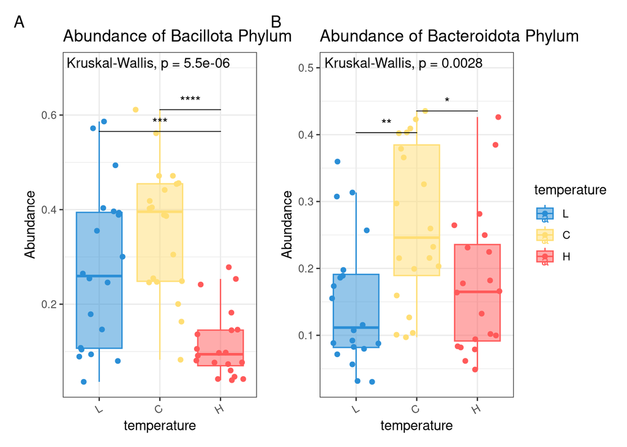

```r
bacil_phylum_temp + bacter_phylum_temp +
  plot_layout(guides = "collect") +
  plot_annotation(tag_levels = "A")
```

eh not necessary, high temp not that separated from the rest, but may be good for comparisons to the paper

## A4:desulfobacterota (not abundant, but v high at control)

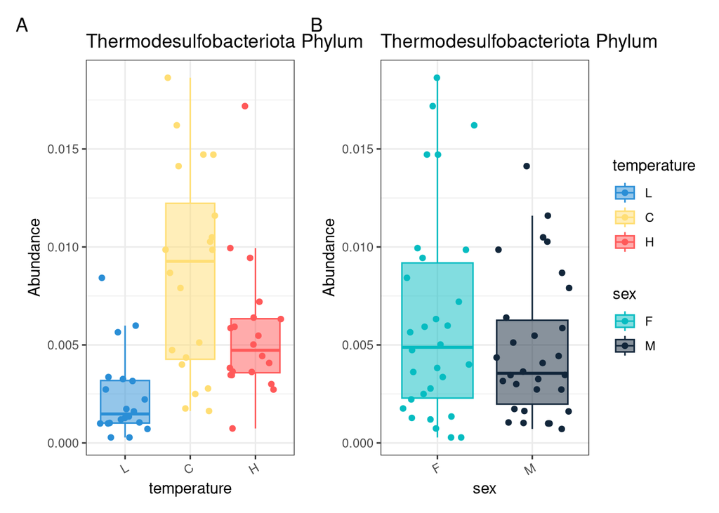

```r
# desulfur - y: abundance, x: station, dot plot + boxplot
thermo_phylum_temp <-
  phylum_df %>%
  dplyr::filter(Phylum == "Thermodesulfobacteriota") %>%
  # build the plot
  ggplot(aes(x = temperature, y = Abundance,
             fill = temperature, color = temperature)) +
  geom_boxplot(alpha = 0.5, outlier.shape = NA) + # outliers not plotted here in boxplot
  geom_jitter() +
  theme_bw() +
  labs(title = "Thermodesulfobacteriota Phylum") +
  scale_color_manual(values = temperature_colors) +
  scale_fill_manual(values = temperature_colors) +
    theme(axis.text.x = element_text(angle = 30, hjust = 1, vjust = 1),
          legend.position = "right")
# Statistically: Kruskall-Wallis followed by a Tukey's Posthoc test
# These are non-parametric (non-normal) stat tests


# SEX
thermo_phylum_sex <-
  phylum_df %>%
  dplyr::filter(Phylum == "Thermodesulfobacteriota") %>%
  # build the plot
  ggplot(aes(x = sex, y = Abundance,
             fill = sex, color = sex)) +
  geom_boxplot(alpha = 0.5, outlier.shape = NA) + # outliers not plotted here in boxplot
  geom_jitter() +
  theme_bw() +
  labs(title = "Thermodesulfobacteriota Phylum") +
  scale_color_manual(values = sex_colors) +
  scale_fill_manual(values = sex_colors) +
    theme(axis.text.x = element_text(angle = 30, hjust = 1, vjust = 1),
          legend.position = "right")
# Statistically: Kruskall-Wallis followed by a Tukey's Posthoc test
# These are non-parametric (non-normal) stat tests

# Collect both of the plots together into one
thermo_phylum_temp + thermo_phylum_sex +
  plot_layout(guides = "collect") +
  plot_annotation(tag_levels = "A")
```

Also maybe not, control probs won’t be significant from high temp

INTERPRETATION #4: Based on these phylum-level analyses, were there any phyla that you were able to identify to focus on moving forward for deeper taxonomic analyses? Why?

Pseudomonadota and Bacillota seemed to have one group (high temp) that is significantly different from the other two. especially bacillota. For Pseudomonadota, the control temperature holds the lowest abundance. Both low temp and high temp display an increase in abundance, suggesting that a disbalance in temperature in either direction allows opportunistic microbes from Pseudomonadota to rise in abundance. For Bacillota, low and control temperatures have similar abundances, but the abundance drops noticeably at high temperatures. This suggests that at high temperatures, bacteria from this phylum are no longer able to survive. For Bacteroidetes and Thermodesulobacteroiota, There is a drop in abundance at both low and high temperatures, however it does not seem to be drastic enough to count as biologically significant. Perhaps it implies though that an imbalance in temperature prevents these bacteria from being as abundant as they should be.

Due to the clear differences between temperature groups in Pseudomonadota and Bacillota, I have decided to move forward with these two phyla, and disregard thermodesulfobacterota

# Create a Genus dataframe

```r
# Calculate the Family relative abundance
# Note: The read depth MUST be normalized in some way: scale_reads
genus_df <-
  scaled_physeq %>%
  # agglomerate at the phylum level
  tax_glom(taxrank = "Genus") %>%
  # Transform counts to relative abundance
  transform_sample_counts(function (x) {x/sum(x)}) %>%
  # Melt to a long format
  psmelt() %>%
  # Fix the order of date
  mutate(temperature = fct_relevel(temperature, c("L", "C", "H")))
```

## B1: Pseudomonadota Genera

Plot relative abundance of genera within Pseudomonadota phylum

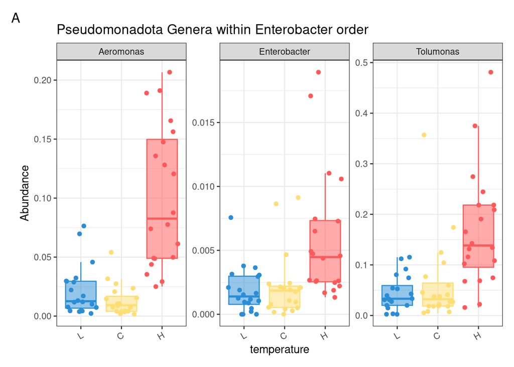

```r
# Actinomycetota:
# I def want enterobacteria, (this is an order, not a genus). maybe other gammaproteo?


#Make boxplots of Pseudomonadota genus
pseudo_df <- subset(genus_df, Order == "Enterobacterales")

# Plot genus
pseudo_genus_temp <-
  genus_df %>%
  dplyr::filter(Phylum == "Pseudomonadota") %>%
  # At first, plot all of the genera and then subset the ones that have intersting trends
  dplyr::filter(Genus %in% c("Tolumonas", "Aeromonas","Enterobacter")) %>%
  # build the plot "Tolumonas", "Aeromonas",
  ggplot(aes(x = temperature, y = Abundance,
             fill = temperature, color = temperature)) +
  facet_wrap(.~Genus, scales = "free_y", nrow = 1) +
  geom_boxplot(alpha = 0.5, outlier.shape = NA) + # outliers not plotted here in boxplot
  geom_jitter() +

  #     stat_compare_means(method = "kruskal.test", label.y = 0.02) +  # KRUSKAL p-value (not normal)
  # geom_pwc(
  #   aes(group = temperature), tip.length = 0, hide.ns = TRUE,
  #   method = "wilcox.test", label = "p.adj.signif",
  #   step.increase = 0.08,
  #   p.adjust.method = "fdr", bracket.nudge.y = -0.08) +

  theme_bw() +
  labs(title = "Pseudomonadota Genera within Enterobacter order") +
  scale_color_manual(values = temperature_colors) +
  scale_fill_manual(values = temperature_colors) +
  theme(axis.text.x = element_text(angle = 30, hjust = 1, vjust = 1),
        legend.position = "none")


# Collect the Actinomycetota Plots
pseudo_genus_temp +
  plot_layout(guides = "collect") +
  plot_annotation(tag_levels = "A")
```

```r
# pseudo_genus_temp_aero + pseudo_genus_temp_ent +
#   pseudo_genus_temp_tolu +
#   plot_layout(guides = "collect") +
#   plot_annotation(tag_levels = "A")
```

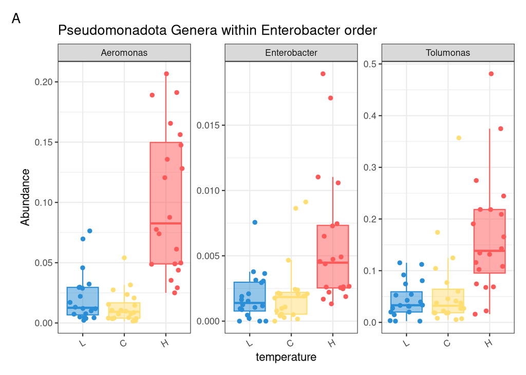

```r
pseudo_df <- subset(genus_df, Phylum == "Pseudomonadota")
categories <- unique(pseudo_df$Genus)

# Plot class
pseudo_class_temp <-
  genus_df %>%
  dplyr::filter(Phylum == "Pseudomonadota") %>%
  # At first, plot all of the genera and then subset the ones that have intersting trends
  dplyr::filter(Class %in% c("Gammaproteobacteria", "Alphaproteobacteria")) %>%
  # build the plot
  ggplot(aes(x = factor(temperature), y = Abundance,
             fill = temperature, color = temperature)) +
  facet_wrap(.~Class, scales = "free_y", nrow = 1) +
  geom_boxplot(alpha = 0.5, outlier.shape = NA) + # outliers not plotted here in boxplot
  geom_jitter() +
  theme_bw() +
  labs(title = "Pseudomonadota Classes") +
  scale_color_manual(values = temperature_colors) +
  scale_fill_manual(values = temperature_colors) +
  theme(axis.text.x = element_text(angle = 30, hjust = 1, vjust = 1),
        legend.position = "none")


# Collect the Pseudo Plots
pseudo_genus_temp +
  plot_layout(guides = "collect") +
  plot_annotation(tag_levels = "A")
```

### Pseudomonadota genera order Burkholderia

Because a lot of our top ASVs are burkholderias

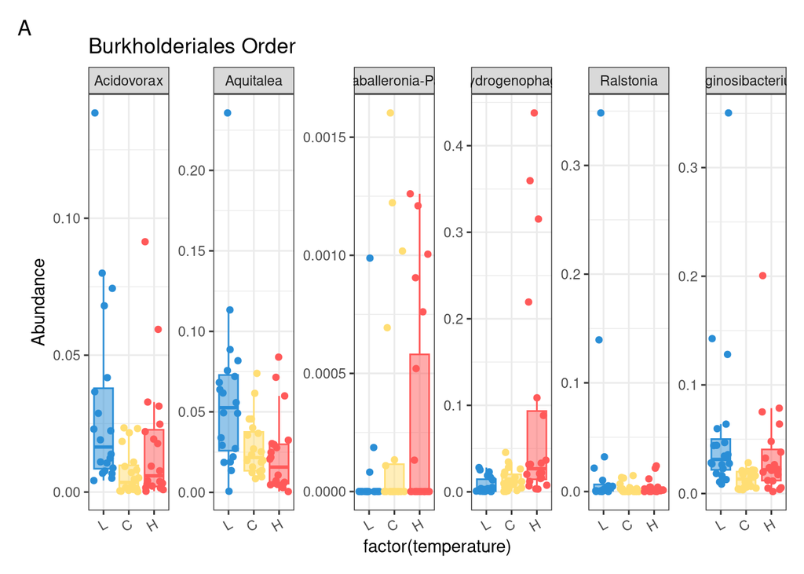

```r
 burk_df <- subset(genus_df, Order == "Burkholderiales")
 categories <- unique(burk_df$Genus)
 # 146 genera in burkholderiales!

# Plot class
burk_genus_temp <-
  genus_df %>%
  dplyr::filter(Order == "Burkholderiales") %>%
  # At first, plot all of the genera and then subset the ones that have intersting trends
  dplyr::filter(Genus %in% c("Hydrogenophaga", "Uliginosibacterium", "Ralstonia", "Aquitalea", "Acidovorax", "Burkholderia-Caballeronia-Paraburkholderia")) %>%
  # build the plot
  ggplot(aes(x = factor(temperature), y = Abundance,
             fill = temperature, color = temperature)) +
  facet_wrap(.~Genus, scales = "free_y", nrow = 1) +
  geom_boxplot(alpha = 0.5, outlier.shape = NA) + # outliers not plotted here in boxplot
  geom_jitter() +
  theme_bw() +
  labs(title = "Burkholderiales Order") +
  scale_color_manual(values = temperature_colors) +
  scale_fill_manual(values = temperature_colors) +
  theme(axis.text.x = element_text(angle = 30, hjust = 1, vjust = 1),
        legend.position = "none")


# Collect the Pseudo Plots
burk_genus_temp +
  plot_layout(guides = "collect") +
  plot_annotation(tag_levels = "A")
```

there were 146 genera in the order Burkholderiales, so I included the top 5 plus “Burkholderia-Caballeronia-Paraburkholderia”. Though 7 of the top `3 ASVs are from this order, none of the plots particularly show a strong change in abundance at any temperature. Burk-Caball-Paraburk, and Hydrogenophaga had many high-abundance outliers at high temperatures, and Acidovorax had high-abundance outliers at low and high temperatures, yet none of these match the overall pattern that is claimed in the paper.

### Make one plot with Enterobacter and Burkholderia orders

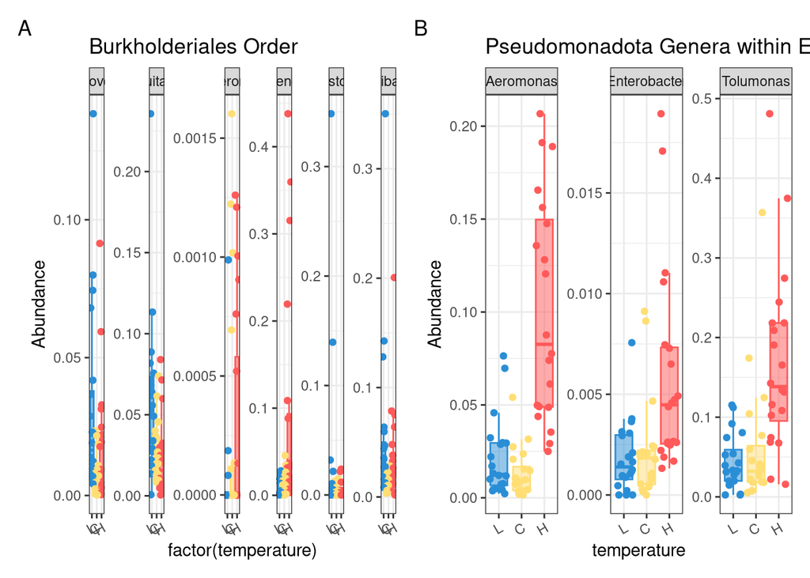

```r
burk_genus_temp + pseudo_genus_temp +
  plot_layout(guides = "collect") +
  plot_annotation(tag_levels = "A")
```

## Bacillota genera, probably lacobacter

Plot relative abundance of genera within Bacillota phylum

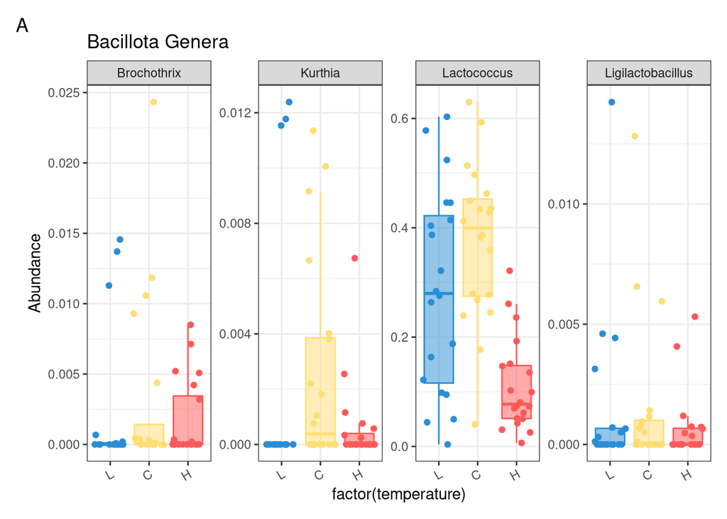

```r
bacil_df <- subset(genus_df, Phylum == "Bacillota")
categories <- unique(bacil_df$Genus)

# Plot class
bacil_genus_temp <-
  genus_df %>%
  dplyr::filter(Phylum == "Bacillota") %>%
  # At first, plot all of the genera and then subset the ones that have intersting trends
  dplyr::filter(Genus %in% c("Lactococcus", "Ligilactobacillus", "Brochothrix", "Kurthia")) %>%
  # build the plot
  ggplot(aes(x = factor(temperature), y = Abundance,
             fill = temperature, color = temperature)) +
  facet_wrap(.~Genus, scales = "free_y", nrow = 1) +
  geom_boxplot(alpha = 0.5, outlier.shape = NA) + # outliers not plotted here in boxplot
  geom_jitter() +
  theme_bw() +
  labs(title = "Bacillota Genera") +
  scale_color_manual(values = temperature_colors) +
  scale_fill_manual(values = temperature_colors) +
  theme(axis.text.x = element_text(angle = 30, hjust = 1, vjust = 1),
        legend.position = "none")


# Collect the Pseudo Plots
bacil_genus_temp +
  plot_layout(guides = "collect") +
  plot_annotation(tag_levels = "A")
```

Bacillota only had the top four general that were abundant at any temperature group. Of these four, only Lactococcus showed any pattern: abundance dropped at high temperatures. The other three genera had many outliers, but the median line of the boxplot was generally very low and equally low between temperature groups. Moving forward, only Lactococcus is interesting.Plus, the Top ASVs from Bacillota are exclusively from the genera Lactococcus.

# ASV Level

create a new dataframe for the ASVs and sanity check the number of unique ASVs in dataset

```r
#how many asv's do I have?
categories <- unique(genus_df$OTU)
# 736 OTUs.
# In the previous HW, I scaled to 39242, so I will remove the taxa that have less than 1%, which is 392


# Calculate the Family relative abundance
# Note: The read depth MUST be normalized in some way: scale_reads
ASV_df <-
  scaled_physeq %>%
  # Prune out ASVs that have fewer than 100 counts!
  ## LOOK AT HOW MANY ARE REMOVED! We scaled to 1,962 reads!
  prune_taxa(taxa_sums(.) >= 392, .) %>%
  # agglomerate at the phylum level
  tax_glom(taxrank = "ASV") %>%
  # Transform counts to relative abundance
  transform_sample_counts(function (x) {x/sum(x)}) %>%
  # Melt to a long format
  psmelt() %>%
  # fix the order of date
  mutate(temperature = fct_relevel(temperature, c("L", "C", "H")))

# Check how many unique ASVs we have now:
categories <- unique(ASV_df$OTU)
# Now we have 317 unique ASVs, basically reduced in half.
# What phyla do we still have?
categories <- unique(ASV_df$Phylum)
phyla_df <- subset(ASV_df, Phylum == "Pseudomonadota")
```

## Pseudomonadota ASVs

Plot relative abundance of top ASVs within Pseudomonadota phylum

[figure not shown]

```r
# Make a list of phyla the top phyla
top_pseudo_ASVs <-
  ASV_df %>%
  dplyr::filter(Phylum == "Pseudomonadota") %>%
  group_by(ASV) %>%
  summarize(mean_Abundance = mean(Abundance)) %>%
  dplyr::filter(mean_Abundance > 0.005) %>%
  pull(ASV)

# Pseudomonadota
# Plot ASVs
pseudo_asv_temp <-
  ASV_df %>%
  dplyr::filter(ASV %in% top_pseudo_ASVs) %>%
  #dplyr::filter(OTU %in% c("ASV_0007", "ASV_0015","ASV_0027", "ASV_0032", "ASV_0031", "ASV_0003","ASV_0021", "ASV_0017")) %>%
  # build the plot
  ggplot(aes(x = temperature, y = Abundance,
             fill = temperature, color = temperature)) +
  facet_wrap(Genus~ASV, scales = "free_y", nrow = 2) +
  geom_boxplot(alpha = 0.5, outlier.shape = NA) + # outliers not plotted here in boxplot
  geom_jitter() +
  theme_bw() +
  labs(title = "Pseudomonadota ASVs") +
  scale_color_manual(values = temperature_colors) +
  scale_fill_manual(values = temperature_colors) +
  theme(axis.text.x = element_text(angle = 30, hjust = 1, vjust = 1),
        legend.position = "none")

# Collect the Actinomycetota Plots
pseudo_asv_temp +
  plot_layout(guides = "collect") +
  plot_annotation(tag_levels = "A")
```

## Bacillota ASVs

```r
# Make a list of phyla the top phyla
top_bacil_ASVs <-
  ASV_df %>%
  dplyr::filter(Phylum == "Bacillota") %>%
  group_by(ASV) %>%
  summarize(mean_Abundance = mean(Abundance)) %>%
  dplyr::filter(mean_Abundance > 0.005) %>%
  pull(ASV)


# What does the bacillota phylum look like?
top_bacil_ASVs <- subset(ASV_df, Phylum == "Bacillota")
# how many classes in bacil do we
categories <- unique(top_bacil_ASVs$OTU)


shapiro.test(top_bacil_ASVs$Abundance)
```

```
##
##  Shapiro-Wilk normality test
##
## data:  top_bacil_ASVs$Abundance
## W = 0.16052, p-value < 2.2e-16
```

```r
# not normal, we can use kruskall wallis test
# Pseudomonadota
# Plot ASVs



# plot boxplot of ASVs within Bacillotas
# bacil_asv_temp <-
#   ASV_df %>%
#   dplyr::filter(ASV %in% top_bacil_ASVs) %>%
#   #dplyr::filter(OTU %in% c("ASV_0029")) %>%
#   # build the plot
#   ggplot(aes(x = temperature, y = Abundance,
#              fill = temperature, color = temperature)) +
#   facet_wrap(Genus~ASV, scales = "free_y", nrow = 2) +
#   geom_boxplot(alpha = 0.5, outlier.shape = NA) + # outliers not plotted here in boxplot
#   geom_jitter() +
#
#   # stat_compare_means(method = "kruskal.test", label.y = 0.02) +  # KRUSKAL p-value (not normal)
#   # geom_pwc(
#   #   aes(group = temperature), tip.length = 0, hide.ns = TRUE,
#   #   method = "wilcox.test", label = "p.adj.signif",
#   #   step.increase = 0.08,
#   #   p.adjust.method = "fdr", bracket.nudge.y = -0.08) +
#   #
#   labs(title = "Bacillota ASVs") +
#   scale_color_manual(values = temperature_colors) +
#   scale_fill_manual(values = temperature_colors) +
#   theme(axis.text.x = element_text(angle = 30, hjust = 1, vjust = 1),
#         legend.position = "none")


# Collect the Actinomycetota Plots
# bacil_asv_temp +
#   plot_layout(guides = "collect") +
#   plot_annotation(tag_levels = "A")
```

The top ASVs dataframe for the Bacillota phylum only contains two ASVs, lactococcus 0001 and lactococcus 0029. The other top Bacillota genera from the genera ASVs did not appear, but it may be that Lactococcus 0001 ASV is a huge percentage of populations and is singlehandedly making up the abundance of Bacillota.

## Burkholderia ASVs spescifically

Plot relative abundance of top ASVs within Burkholderiales order

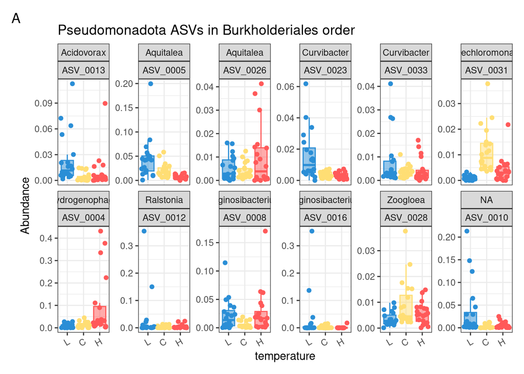

```r
# Pseudomonadota
# Plot ASVs
burk_asv_temp <-
  ASV_df %>%
  dplyr::filter(ASV %in% top_pseudo_ASVs) %>%
  dplyr::filter(Order == "Burkholderiales") %>%
  #dplyr::filter(OTU %in% c("ASV_0007", "ASV_0015","ASV_0027", "ASV_0032", "ASV_0031", "ASV_0003","ASV_0021", "ASV_0017")) %>%
  # build the plot
  ggplot(aes(x = temperature, y = Abundance,
             fill = temperature, color = temperature)) +
  facet_wrap(Genus~ASV, scales = "free_y", nrow = 2) +
  geom_boxplot(alpha = 0.5, outlier.shape = NA) + # outliers not plotted here in boxplot
  geom_jitter() +
  theme_bw() +
  labs(title = "Pseudomonadota ASVs in Burkholderiales order") +
  scale_color_manual(values = temperature_colors) +
  scale_fill_manual(values = temperature_colors) +
  theme(axis.text.x = element_text(angle = 30, hjust = 1, vjust = 1),
        legend.position = "none")

# Collect the Actinomycetota Plots
burk_asv_temp +
  plot_layout(guides = "collect") +
  plot_annotation(tag_levels = "A")
```

```r
head(genus_df %>% filter(OTU == "ASV_0004"), 1)
```

```
##        OTU      Sample Abundance Assay.Type AvgSpotLen    Bases  BioProject
## 1 ASV_0004 SRR19509147  0.437891   AMPLICON        500 54659500 PRJNA843708
##      BioSample              BioSampleModel    Bytes                 Center.Name
## 1 SAMN28766930 Metagenome or environmental 17620533 NANJING FORESTRY UNIVERSITY
##   Collection_Date Consent DATASTORE.filetype DATASTORE.provider
## 1         2021-10  public   fastq,run.zq,sra         ncbi,s3,gs
##                       DATASTORE.region  Experiment geo_loc_name_country
## 1 gs.us-east1,s3.us-east-1,ncbi.public SRX15561686                China
##   geo_loc_name_country_continent  geo_loc_name                 Host
## 1                           Asia China: Suzhou Pomacea canaliculata
##              Instrument isolation_source            lat_lon Library.Name
## 1 Illumina NovaSeq 6000    gut content16 30.916 N 120.403 E          HF1
##   LibraryLayout LibrarySelection LibrarySource       Organism Platform
## 1        PAIRED              PCR   METAGENOMIC gut metagenome ILLUMINA
##   ReleaseDate         create_date version Sample.Name SRA.Study       names
## 1  2024-05-30 2022-06-01 14:59:00       1         HF1 SRP378042 SRR19509147
##   denoisedF denoisedR merged nochim num_ASVs snail_exp_group_name temperature
## 1     96238     96115  89969  68794      404                   HF           H
##   sex  Kingdom         Phylum               Class           Order
## 1   F Bacteria Pseudomonadota Gammaproteobacteria Burkholderiales
##           Family          Genus
## 1 Comamonadaceae Hydrogenophaga
```

## Bacteroidetes ASVs specifically (are there any top asv’s?)

```r
# Make a list of phyla the top phyla
top_bacter_ASVs <-
  ASV_df %>%
  dplyr::filter(Phylum == "Bacteroidota") %>%
  group_by(ASV) %>%
  summarize(mean_Abundance = mean(Abundance)) %>%
  dplyr::filter(mean_Abundance > 0.005) %>%
  pull(ASV)

bacter_asv_temp_19 <-
  ASV_df %>%
  dplyr::filter(ASV %in% top_bacter_ASVs) %>%
  dplyr::filter(OTU %in% c("ASV_0019")) %>%
  # build the plot
  ggplot(aes(x = temperature, y = Abundance,
             fill = temperature, color = temperature)) +
  facet_wrap(Genus~ASV, scales = "free_y", nrow = 2) +
  geom_boxplot(alpha = 0.5, outlier.shape = NA) + # outliers not plotted here in boxplot
  geom_jitter() +

  stat_compare_means(method = "kruskal.test", label.y = 0.08) +  # KRUSKAL p-value (not normal)
  geom_pwc(
    aes(group = temperature), tip.length = 0, hide.ns = TRUE,
    method = "wilcox.test", label = "p.adj.signif",
    step.increase = 0.08,
    p.adjust.method = "fdr", bracket.nudge.y = -0.08) +

  labs(title = "Bacteroidetes ASVs") +
  scale_color_manual(values = temperature_colors) +
  scale_fill_manual(values = temperature_colors) +
  theme(axis.text.x = element_text(angle = 30, hjust = 1, vjust = 1),
        legend.position = "none")


# bacter_asv_temp_02 + bacter_asv_temp_11 + bacter_asv_temp_19 +
#   plot_layout(guides = "collect") +
#   plot_annotation(tag_levels = "A")
```

INTERPRETATION #6: Were the most abundant ASVs in your dataset represented in your ASV-level plots? If not, please go back and plot them specifically. (Hint: Remember that we ordered our ASV names by abundance across the entire dataset. Therefore, ASV_0001 will be the most abundant, ASV_0007 will be the 7th most abundant and so on.)

The top ASVs dataframe for the Bacillota phylum only contains two ASVs, lactococcus 0001 and lactococcus 0029. The other top Bacillota genera from the genera ASVs did not appear, but it may be that Lactococcus 0001 ASV is a huge percentage of populations and is singlehandedly making up the abundance of Bacillota.

INTERPRETATION #7: Please make some plots at the ASV level as it relates to your scientific question. Were there any ASVs that were especially related to trends that you saw? Did a specific phylogenetic group all show the same trends (e.g. like the Actinomycetota ASVs above)? Or did the ASVs have various, likely niche-specific responses (similar to the Cyanobacteriota above)??

INTERPRETATION #8: Now, do a quick literature or google search and look back in the paper that you may be replicating (if applicable). Does your ASV-level changes represent something that is currently known? Or is this a novel result? What did you learn about this ASV or a group of ASVs in your dataset?